# homework3

James(Changhwan) Han (3923257)

4/13/2022

```r
library(tidymodels)
library(ISLR) # For the Smarket data set
library(ISLR2) # For the Bikeshare data set
library(discrim)
library(poissonreg)
library(corrr)
library(klaR) # for naive bayes
tidymodels_prefer()

library(tidyverse)
library(tidymodels)
```

```r
titanic <- read_csv("titanic.csv")
head(titanic)
```

```
## # A tibble: 6 x 12
##   passenger_id survived pclass name  sex     age sib_sp parch ticket  fare cabin
##          <dbl> <chr>     <dbl> <chr> <chr> <dbl>  <dbl> <dbl> <chr>  <dbl> <chr>
## 1            1 No            3 Brau~ male     22      1     0 A/5 2~  7.25 <NA>
## 2            2 Yes           1 Cumi~ fema~    38      1     0 PC 17~ 71.3  C85
## 3            3 Yes           3 Heik~ fema~    26      0     0 STON/~  7.92 <NA>
## 4            4 Yes           1 Futr~ fema~    35      1     0 113803 53.1  C123
## 5            5 No            3 Alle~ male     35      0     0 373450  8.05 <NA>
## 6            6 No            3 Mora~ male     NA      0     0 330877  8.46 <NA>
## # ... with 1 more variable: embarked <chr>
```

```r
titanic$survived <- factor(titanic$survived, levels = c('Yes', 'No'))
titanic$pclass <- factor(titanic$pclass)


levels(titanic$survived)
```

```
## [1] "Yes" "No"
```

# Question 1

```r
set.seed(1996)

titanic_split <- initial_split(titanic, prop = 0.80,
                                strata = survived)
titanic_train <- training(titanic_split)
titanic_test <- testing(titanic_split)

dim(titanic_train)
```

```
## [1] 712  12
```

```r
dim(titanic_test)
```

```
## [1] 179  12
```

```r
sum(is.na(titanic))
```

```
## [1] 866
```

1. Number of observations? train data: 712 test data: 179
2. Potential issues? There are 866 missing values in the dataset and we have to think about how to deal with missing values. Also, we might want to change categoric columns(sex, embarked) to numeric. Additionally we have to consider what columns to use to predict which passengers would survive.
3. Why using stratified sampling? If we do not split the data into different sets the model would be evaluated on the same data it has seen during training. We could avoid overfitting by stratifying sampling.

# Question 2

```r
table(titanic$survived)
```

```
##
## Yes  No
## 342 549
```

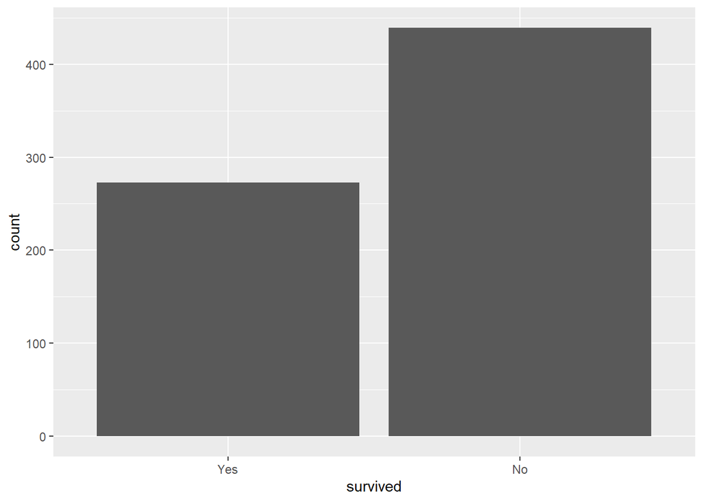

```r
ggplot(titanic_train, aes(x=survived)) + geom_bar()
```

1) describe the distribution of the outcome survived. People who didn’t survive consists approximately 62% of the total number of people.

# Question 3

```r
# cor_titanic_train <- titanic_train %>%
#   select(-passenger_id, -survived, -pclass, -name, -sex, -ticket, -cabin, -embarked) %>%
#   cor(use = "pairwise.complete.obs", method = "pearson")
# rplot(cor_titanic_train)

cor_titanic_train <- titanic_train %>%
  select(is.numeric) %>%
  correlate()
```

```
##
## Correlation method: 'pearson'
## Missing treated using: 'pairwise.complete.obs'
```

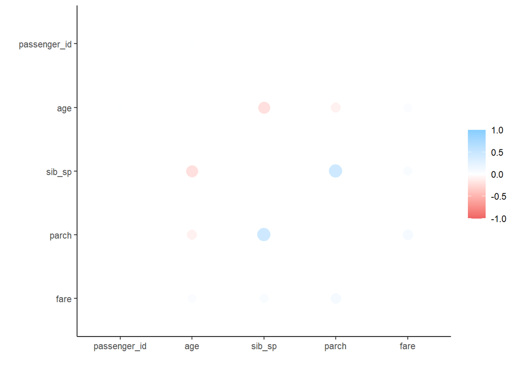

```r
rplot(cor_titanic_train)
```

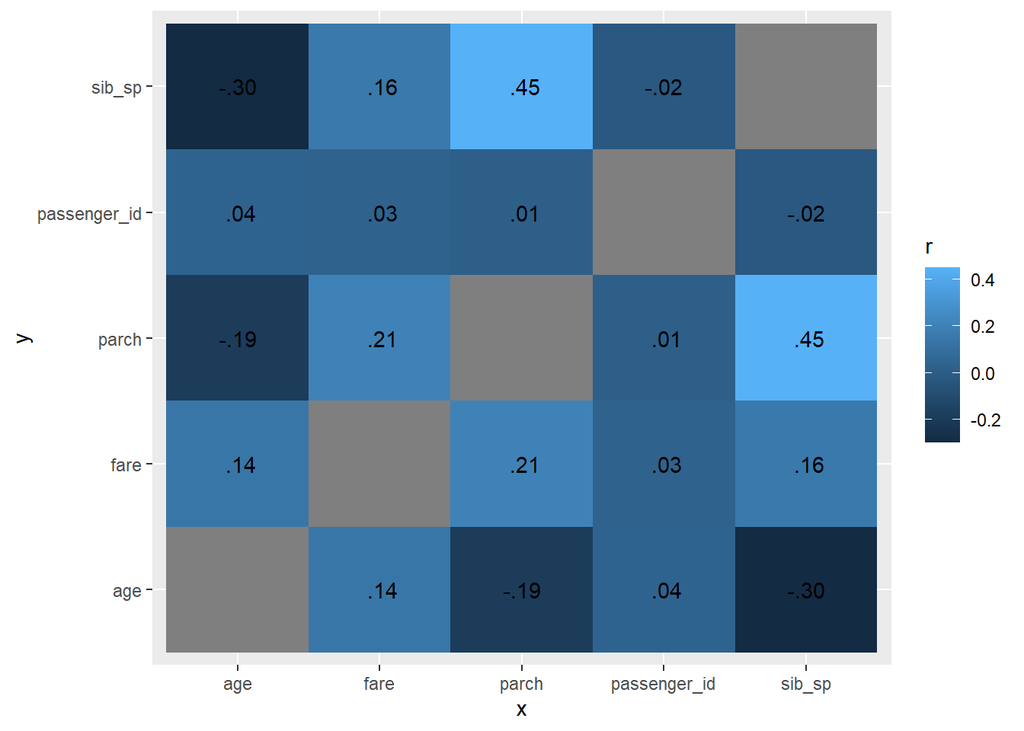

```r
cor_titanic_train %>%
  stretch() %>%
  ggplot(aes(x, y, fill = r)) +
  geom_tile() +
  geom_text(aes(label = as.character(fashion(r))))
```

1) Are any predictors correlated with each other? Which ones, and in which direction? positive numbers from the above indicate that two variables have positive correlation. On the other hand, negative numbers from the above indicate that two variables have negative correlations.

# Question 4

```r
titanic_recipe <- recipe(survived ~ pclass + sex + age + sib_sp + parch + fare,
                         data = titanic_train) %>%
  step_impute_linear(age) %>%
  step_dummy(all_nominal_predictors()) %>%
  step_interact(terms = ~ starts_with("sex"):fare + age:fare)
```

# Question 5

```r
log_reg <- logistic_reg() %>%
  set_engine("glm") %>%
  set_mode("classification")

log_wkflow <- workflow() %>%
  add_model(log_reg) %>%
  add_recipe(titanic_recipe)

log_fit <- fit(log_wkflow, titanic_train)
```

# Question 6

```r
lda_mod <- discrim_linear() %>%
  set_mode("classification") %>%
  set_engine("MASS")

lda_wkflow <- workflow() %>%
  add_model(lda_mod) %>%
  add_recipe(titanic_recipe)

lda_fit <- fit(lda_wkflow, titanic_train)
```

# Question 7

```r
qda_mod <- discrim_quad() %>%
  set_mode("classification") %>%
  set_engine("MASS")

qda_wkflow <- workflow() %>%
  add_model(qda_mod) %>%
  add_recipe(titanic_recipe)

qda_fit <- fit(qda_wkflow, titanic_train)
```

# Question 8

```r
nb_mod <- naive_Bayes() %>%
  set_mode("classification") %>%
  set_engine("klaR") %>%
  set_args(usekernel = FALSE)

nb_wkflow <- workflow() %>%
  add_model(nb_mod) %>%
  add_recipe(titanic_recipe)

nb_fit <- fit(nb_wkflow, titanic_train)
```

# Question 9

```r
# log_reg_acc <- augment(log_fit, new_data = titanic_train) %>%
#   accuracy(truth = survived, estimate = .pred_class)
#
# lda_acc <- augment(lda_fit, new_data = titanic_train) %>%
#   accuracy(truth = survived, estimate = .pred_class)
#
# qda_acc <- augment(qda_fit, new_data = titanic_train) %>%
#   accuracy(truth = survived, estimate = .pred_class)
#
# nb_acc <- augment(nb_fit, new_data = titanic_train) %>%
#   accuracy(truth = survived, estimate = .pred_class)
#
#
# accuracies <- c(log_reg_acc$.estimate, lda_acc$.estimate, qda_acc$.estimate, nb_acc$.estimate)
# models <- c("Logistic Regression", "LDA", "QDA", "Naive Bayes")
# results <- tibble(accuracies = accuracies, models = models)
# results %>%
#   arrange(-accuracies)

bound_train_data = bind_cols(predict(log_fit, new_data = titanic_train, type = "class"),
                             predict(lda_fit, new_data = titanic_train, type = "class"),
                             predict(qda_fit, new_data = titanic_train, type = "class"),
                             predict(nb_fit, new_data = titanic_train, type = "class"),
                             titanic_train$survived)
```

```
## * .pred_class -> .pred_class...1
## * .pred_class -> .pred_class...2
## * .pred_class -> .pred_class...3
## * .pred_class -> .pred_class...4
## * NA -> ...5
```

```r
colnames(bound_train_data) = c("Log fit", "LDA fit", "QDA fit", "NB fit", "True")

log_reg_acc <- augment(log_fit, new_data = titanic_train) %>%
  accuracy(truth = survived, estimate = .pred_class)


lda_acc <- augment(lda_fit, new_data = titanic_train) %>%
  accuracy(truth = survived, estimate = .pred_class)


qda_acc <- augment(qda_fit, new_data = titanic_train) %>%
  accuracy(truth = survived, estimate = .pred_class)


nb_acc <- augment(nb_fit, new_data = titanic_train) %>%
  accuracy(truth = survived, estimate = .pred_class)

log_reg_acc
```

```
## # A tibble: 1 x 3
##   .metric  .estimator .estimate
##   <chr>    <chr>          <dbl>
## 1 accuracy binary         0.817
```

```r
lda_acc
```

```
## # A tibble: 1 x 3
##   .metric  .estimator .estimate
##   <chr>    <chr>          <dbl>
## 1 accuracy binary         0.803
```

```r
qda_acc
```

```
## # A tibble: 1 x 3
##   .metric  .estimator .estimate
##   <chr>    <chr>          <dbl>
## 1 accuracy binary         0.788
```

```r
nb_acc
```

```
## # A tibble: 1 x 3
##   .metric  .estimator .estimate
##   <chr>    <chr>          <dbl>
## 1 accuracy binary         0.774
```

training set of logistic regression had the highest accuarcy among the four.

# Question 10

```r
predict(log_fit, new_data = titanic_test, type = "prob")
```

```
## # A tibble: 179 x 2
##    .pred_Yes .pred_No
##        <dbl>    <dbl>
##  1     0.970  0.0297
##  2     0.459  0.541
##  3     0.346  0.654
##  4     0.110  0.890
##  5     0.618  0.382
##  6     0.998  0.00230
##  7     0.617  0.383
##  8     0.288  0.712
##  9     0.110  0.890
## 10     0.946  0.0543
## # ... with 169 more rows
```

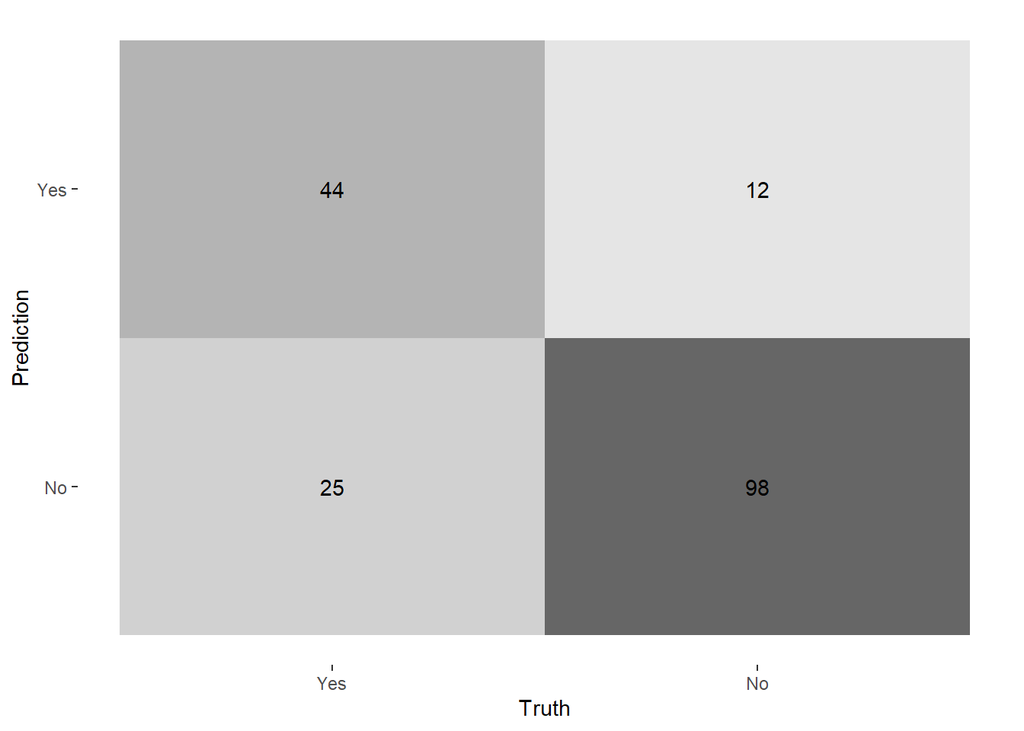

```r
augment(log_fit, new_data = titanic_test) %>%
  conf_mat(truth = survived, estimate = .pred_class) %>%
  autoplot(type = "heatmap")
```

```r
augment(log_fit, new_data = titanic_test) %>%
  roc_auc(truth = survived, estimate = .pred_Yes)
```

```
## # A tibble: 1 x 3
##   .metric .estimator .estimate
##   <chr>   <chr>          <dbl>
## 1 roc_auc binary         0.849
```

```r
multi_metric <- metric_set(accuracy, sensitivity, specificity)

augment(nb_fit, new_data = titanic_test) %>%
  multi_metric(truth = survived, estimate = .pred_class)
```

```
## # A tibble: 3 x 3
##   .metric  .estimator .estimate
##   <chr>    <chr>          <dbl>
## 1 accuracy binary         0.743
## 2 sens     binary         0.478
## 3 spec     binary         0.909
```

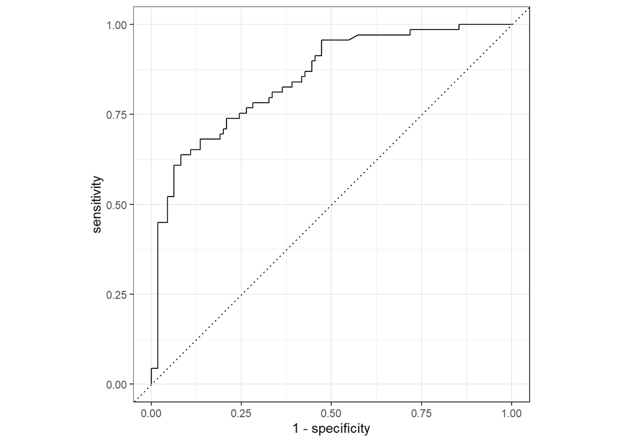

```r
augment(log_fit, new_data = titanic_test) %>%
  roc_curve(survived, .pred_Yes) %>%
  autoplot()
```

# Question 11

$$p(z)=\frac{e^{z}}{1+e^{z}} \leftrightarrow p=\frac{e^{z}}{1+e^{z}}$$
$$\begin{aligned}
&\leftrightarrow \quad p\left(1+e^{z}\right)=e^{z} \\
&\leftrightarrow \quad p+p e^{z}=e^{z} \\
&\leftrightarrow \quad e^{z}(1-p)=p \\
&\leftrightarrow \quad e^{z}=\frac{p}{1-p} \\
&\leftrightarrow \quad z=\ln \left(\frac{p}{1-p}\right) \\
&\leftrightarrow \quad z(p)=\ln \left(\frac{p}{1-p}\right)
\end{aligned}$$

# Question 12

If you increase $x_1$ by two, the odds of the outcome will increase by $2\beta_{1}$.  
$z=\beta_{0}+\beta_{1} x_{1}, \quad P(z)=\frac{e^{z}}{1+e^{z}}$

1. Assuming $\beta_{1}$ is negative and $x_{1} \rightarrow \infty$, $p=\lim _{x_{1} \rightarrow \infty} \frac{e^{\beta_{0}+\beta_{1} x_{1}}}{1+e^{\left(\beta_{0}+\beta_{1} x_{1}\right)}} \Rightarrow \lim _{z\rightarrow-\infty} \frac{e^{z}}{1+e^{z}} \Rightarrow \frac{0}{1+0} = 0$
2. Assuming $\beta_{1}$ is negative and $x_{1} \rightarrow-\infty$,
   $$\begin{aligned}
   p=\lim _{x_{1} \rightarrow \infty} \frac{e^{\beta_{0}+\beta_{1} x_{1}}}{1+e^{\left(\beta_{0}+\beta_{1} x_{1}\right)}} & \Rightarrow \lim _{z \rightarrow \infty} \frac{e^{z}}{1+e^{z}} \\
   & \Rightarrow \lim _{z \rightarrow \infty} \frac{1}{\frac{1}{e^{z}}+1} \\
   & \Rightarrow \frac{1}{0+1}=1
   \end{aligned}$$